#### Hey there ! In this script we’d be creating some new features and then we’d take a look at how those relate with the outcome variable.

#### Along with that we’d take a look at a some variables which makes us raise an eyebrow because of some fishy values that they contain. We’d try to clean them too.

### Dimensions of data

```
## [1] 30471   292
```

### Structure of data

```
## 'data.frame':    30471 obs. of  292 variables:
##  $ id                                   : int  1 2 3 4 5 6 7 8 9 10 ...
##  $ timestamp                            : Date, format: "2011-08-20" "2011-08-23" ...
##  $ full_sq                              : int  43 34 43 89 77 67 25 44 42 36 ...
##  $ life_sq                              : int  27 19 29 50 77 46 14 44 27 21 ...
##  $ floor                                : int  4 3 2 9 4 14 10 5 5 9 ...
##  $ max_floor                            : chr  NA NA NA NA ...
##  $ material                             : chr  NA NA NA NA ...
##  $ build_year                           : chr  NA NA NA NA ...
##  $ num_room                             : chr  NA NA NA NA ...
##  $ kitch_sq                             : chr  NA NA NA NA ...
##  $ state                                : chr  NA NA NA NA ...
##  $ product_type                         : chr  "Investment" "Investment" "Investment" "Investment" ...
##  $ sub_area                             : chr  "Bibirevo" "Nagatinskij Zaton" "Tekstil'shhiki" "Mitino" ...
##  $ area_m                               : num  6407578 9589337 4808270 12583536 8398461 ...
```

[output cut: 86 more lines]

### Missing values

```
##  num                               feature missing_ratio
##    4                               life_sq   20.94778642
##    5                                 floor    0.54806209
##    6                             max_floor   31.41347511
##    7                              material   31.41347511
##    8                            build_year   44.64901053
##    9                              num_room   31.41347511
##   10                              kitch_sq   31.41347511
##   11                                 state   44.49804732
##   19                       preschool_quota   21.94873814
##   22                          school_quota   21.93889272
##   25                   hospital_beds_raion   47.39260280
##   69  raion_build_count_with_material_info   16.37950839
##   70                     build_count_block   16.37950839
##   71                      build_count_wood   16.37950839
```

[output cut: 37 more lines]

Total features with missing values

```
## [1] 51
```

So lot of variables with missing values. 51 out of 292 features have missing data. Some of them have high percentage of missing values.

### Variables with almost zero variance

```
##  [1] "culture_objects_top_25_raion" "oil_chemistry_raion"
##  [3] "railroad_terminal_raion"      "nuclear_reactor_raion"
##  [5] "build_count_foam"             "big_road1_1line"
##  [7] "railroad_1line"               "office_sqm_500"
##  [9] "trc_sqm_500"                  "cafe_count_500_price_4000"
## [11] "cafe_count_500_price_high"    "mosque_count_500"
## [13] "leisure_count_500"            "office_sqm_1000"
## [15] "trc_sqm_1000"                 "cafe_count_1000_price_high"
## [17] "mosque_count_1000"            "cafe_count_1500_price_high"
## [19] "mosque_count_1500"            "cafe_count_2000_price_high"
```

The above variables are not going to help in predictive models. It is better to remove them.

### Extracting date, month, year, weekday from timestamp

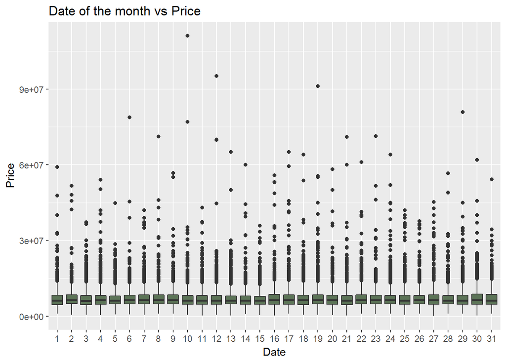

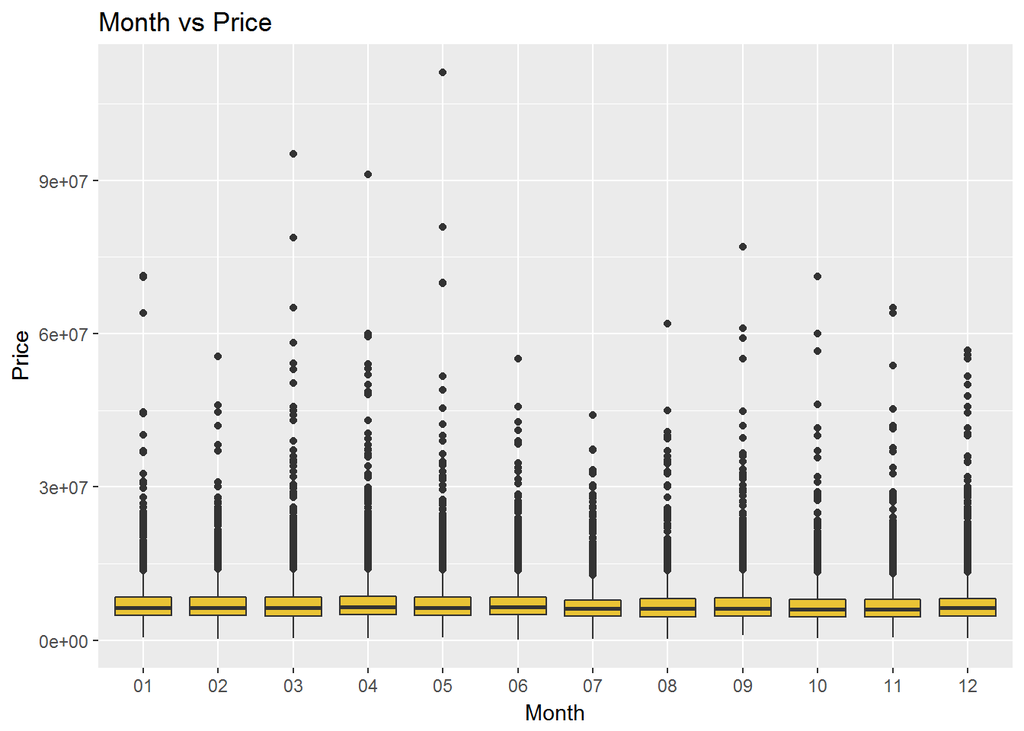

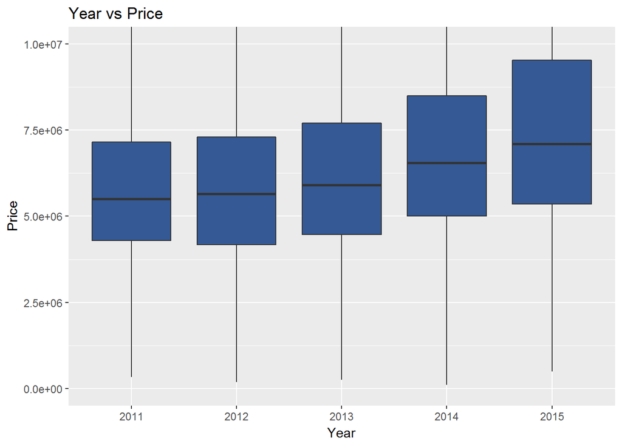

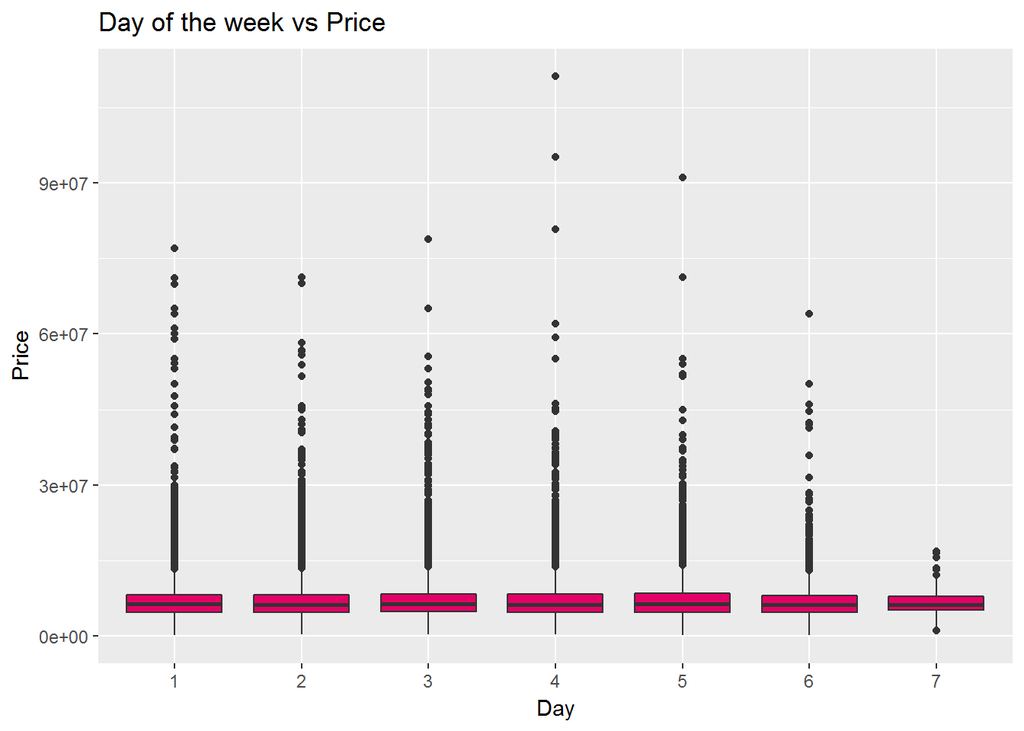

An upward trend with each passing year. But no trend with months, days or weekdays.

## Creating new Features !

This involves cleaning some variables that are already present.

### Build year

Let us look at the distrbution table of Build_Year.

```
##
##        0        1     1691     1860     1876     1886     1890     1895
##      530      368        1        2        1        1        5        1
##     1896     1900     1904     1905     1906     1907     1910     1911
##        2        2        1        1        1        2        5        1
##     1912     1914     1915     1917     1920     1924     1925     1926
##        5        3        5       16        1        3        1        8
##     1927     1928     1929     1930     1931     1932     1933     1934
##       10       12       12        6        6        8        7       13
##     1935     1936     1937     1938     1939     1940     1941     1943
##       11        5       10        9        7       14        2        2
##     1946     1947     1948     1949     1950     1951     1952     1953
##        2        4        1        3       22       23       45       24
##     1954     1955     1956     1957     1958     1959     1960     1961
##       36       52       48      119      179      208      344      297
```

[output cut: 16 more lines]

Needs a little cleaning. I’m replacing the values values like 0,1,2 with NA

```r
rus$build_year <- as.character(rus$build_year)

rus$build_year[rus$build_year == "20052009"] <- "2005"
rus$build_year[rus$build_year == "0"] <- NA
rus$build_year[rus$build_year == "1"] <- NA
rus$build_year[rus$build_year == "20"] <- "2000"
rus$build_year[rus$build_year == "215"] <- "2015"
rus$build_year[rus$build_year == "3"] <- NA
rus$build_year[rus$build_year == "4965"] <- NA
rus$build_year[rus$build_year == "71"] <- NA

rus$build_year <- as.integer(rus$build_year)
```

### Let us create a new variable. Year_Old = 2020 - Build_Year

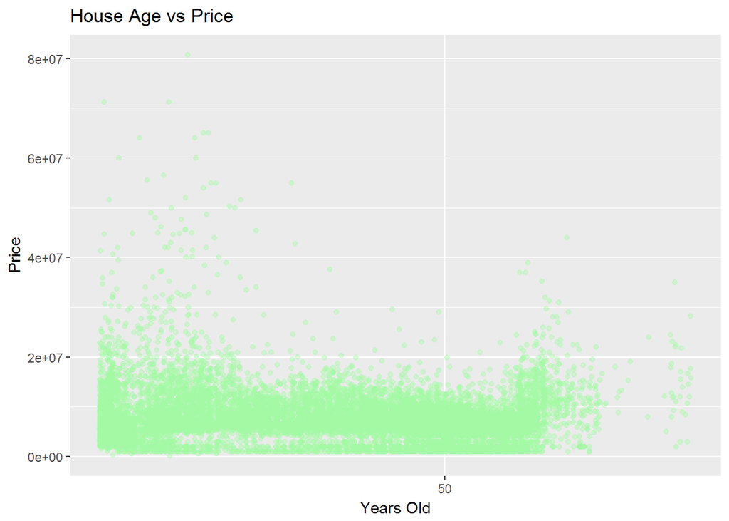

### Floor Inverse

The new variable is floor_inverse If a building has 100 floors and a specific house is on 40th floor then the floor_proportion would be 100 - 40 = 60

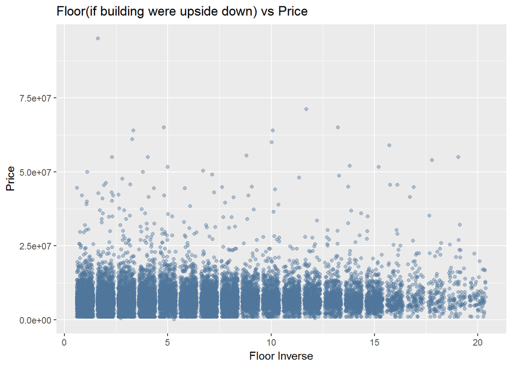

### Non-residential area to living area ratio

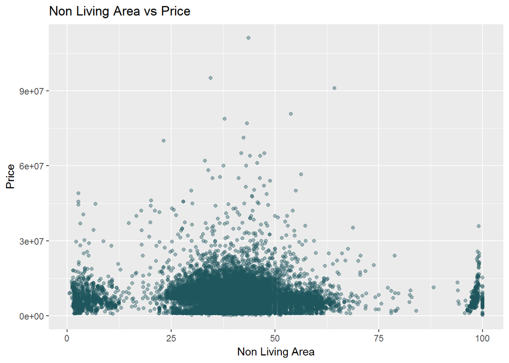

### Area per Room

This is calculated by dividing total living area by number of rooms

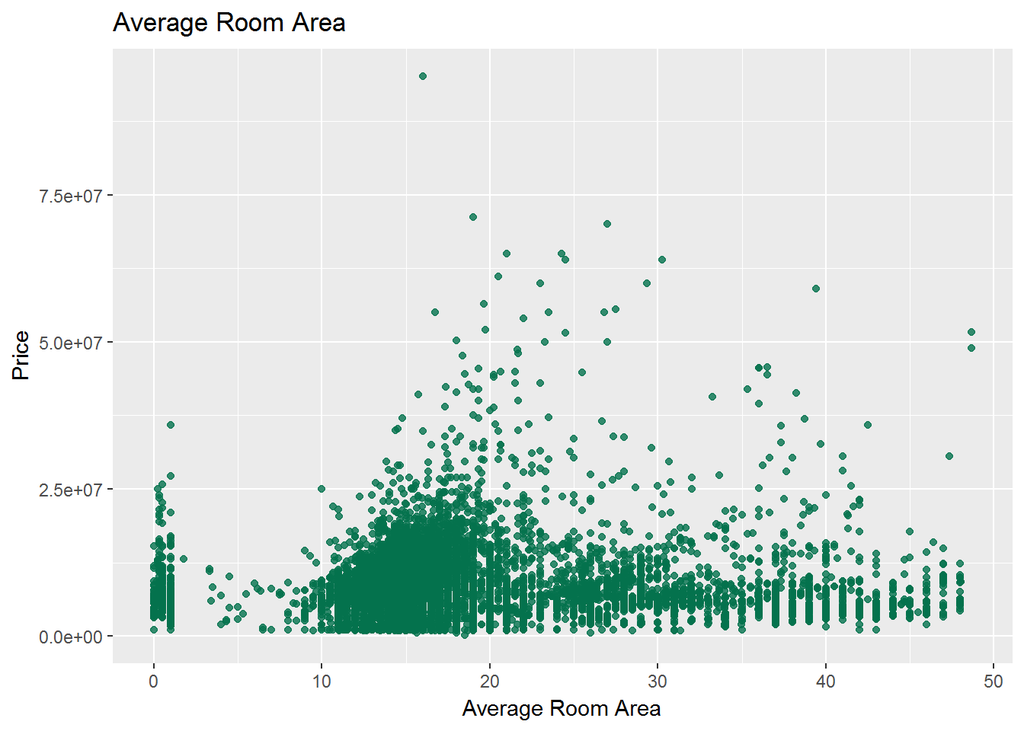

### State of the apartment

```
##
##    1    2    3   33    4
## 4855 5844 5790    1  422
```

“33” seems to be an odd value. So replace “33” with “3”

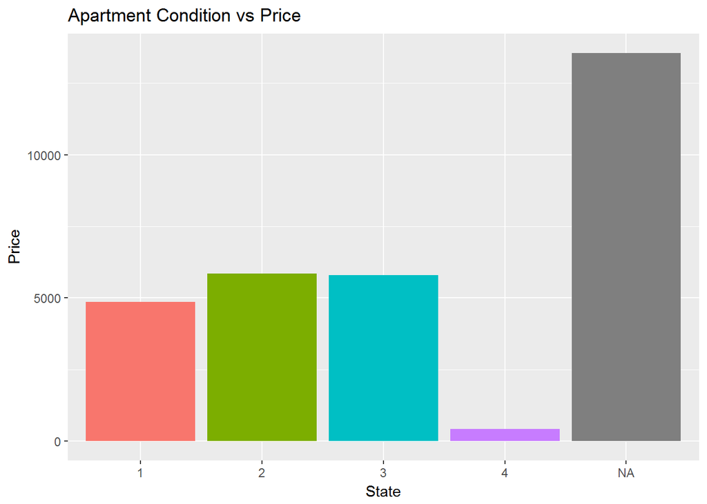

### ID features

Features which have ID in their name are not much of a use to predictive model. So it is better to remove them. All these features start with id_*

Following features have id in their names.

```
## [1] "id"                       "id_metro"
## [3] "id_railroad_station_walk" "id_railroad_station_avto"
## [5] "id_big_road1"             "id_big_road2"
## [7] "id_railroad_terminal"     "id_bus_terminal"
```

There is a lot of cleaning to be done. We can try to impute the missing values because some models can’t handle missing values. I tried knn imputation but it did not improve the performance of XGBOOST model.

Stay tuned for more feature engineering.

### Please like the kernel. Your likes are my motivation. ;)